# Week 5 exercise

Narges Rezaie

Feb, 2020

```r
library(ggplot2)
library(ggpubr)
```

### Plotting basics in base R

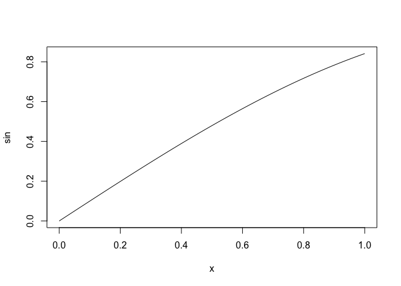

```r
plot(sin)
```

Change it so that the `x` axis label is $\sigma$ and the `y` axis label is $\tau$. Those are the Greek letters “sigma” and “tau”, respectively.

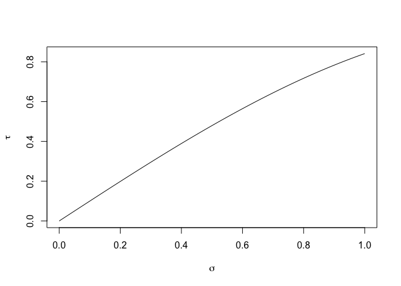

```r
plot(sin, xlab = expression(sigma), ylab = expression(tau))
```

Take the same plot, and change the `x` axis label to $\sigma^2_s$.

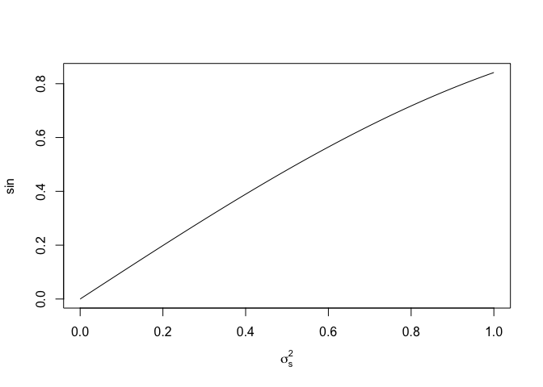

```r
plot(sin, xlab=expression(sigma[s]^2))
```

#### Color and line style (base graphics)

For the same plot as above, change the plot so that the line is red, “dot-dash”, and 3 times the default line thickness.

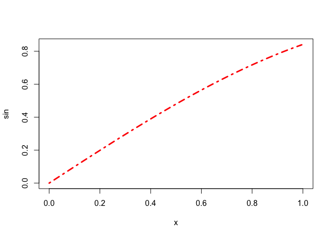

```r
plot(sin, col = "red", lty = 4, lwd = 3)
```

#### Axis labels from data

Take the graph we started with, and assume there’s a variable `y = 7`. Add a title to the graph that says $\Gamma = 7$. (That’s the Greek letter “gamma”.) Do it using the variable! Don’t “hard-code” in the value!

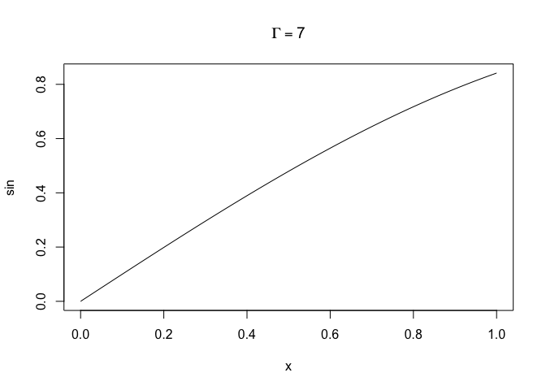

```r
y = 7
plot(sin, main = bquote(Gamma == .(y)))
```

#### Annotations from data

Take the graph we started with, and assume there’s a variable `y = 7`. Add a text element at coordinates `x=0.1, y=0.4` to the graph that says $\Gamma = 7$.

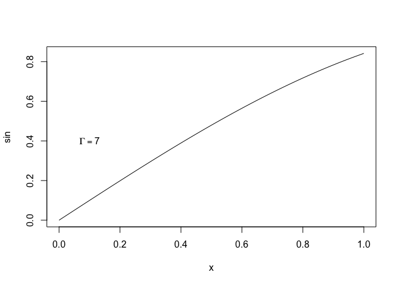

```r
y = 7
plot(sin)
text(x=0.1, y=0.4, bquote(Gamma == .(y)))
```

#### Saving files

Save one of your graphics in the following formats:

- pdf with 18 point font, 10" by 10" square
- tiff with 18 point font, 10" by 10" square and the x axis font is 1/2 the global font size.
- 72 dpi png with 18 point font, 10" by 10" square
- 300 dpi png with 18 point font, 10" by 10" square

### R/ggplot

Take the following ggplot:

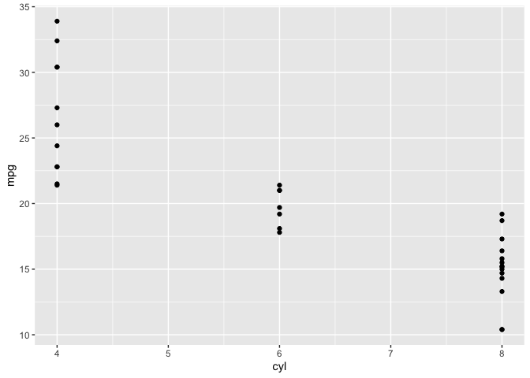

```r
library(ggplot2)
data(mtcars)
p = ggplot(mtcars, aes(x=cyl, y = mpg)) + geom_point()
print(p)
```

Repeat the various manipulations above. Where the above instructions refer to lines, change point color/size/shape instead.

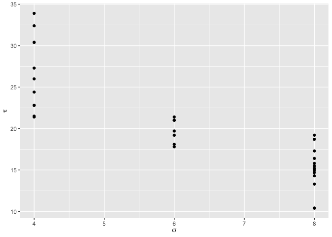

```r
p1 = p + xlab(expression(sigma)) + ylab(expression(tau))
print(p1)
```

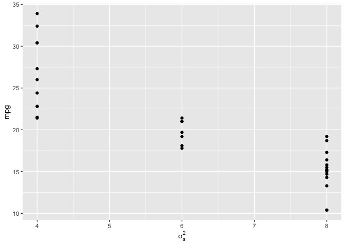

```r
p2 = p + xlab(expression(sigma[s]^2))
print(p2)
```

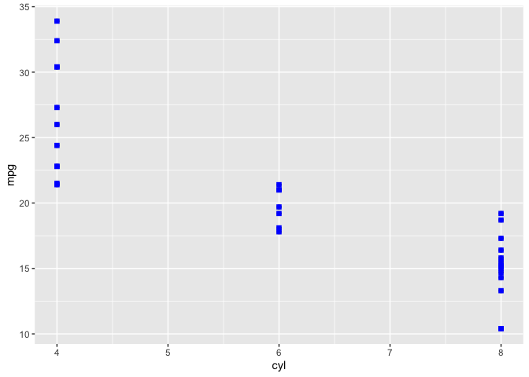

```r
p3 = p + geom_point(color='blue', size=2, shape= 15)
print(p3)
```

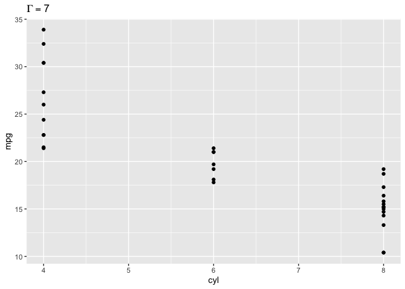

```r
y = 7
p4 = p + ggtitle(bquote(Gamma == .(y)))
print(p4)
```

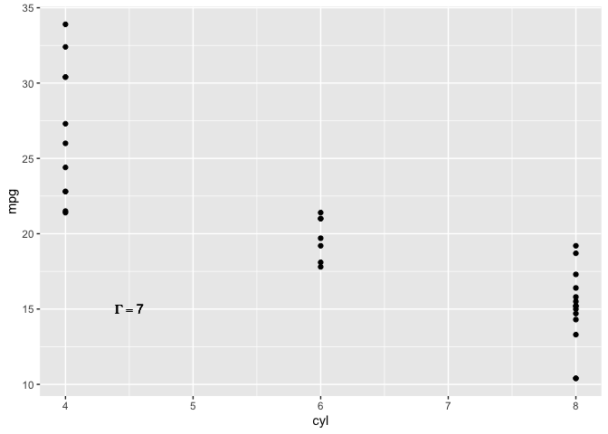

```r
y = 7
p + annotate("text",label = bquote(Gamma == .(y)), x = 4.5, y = 15)
```

Also, use the `ggpubr` library to plot two ggplots side by side.

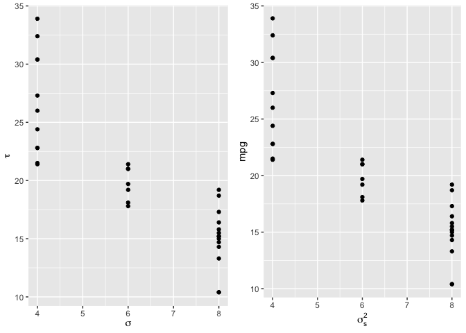

```r
ggarrange(p1, p2, ncol = 2)
```

Do it again, but as a 2x2 matrix of 4 plots.

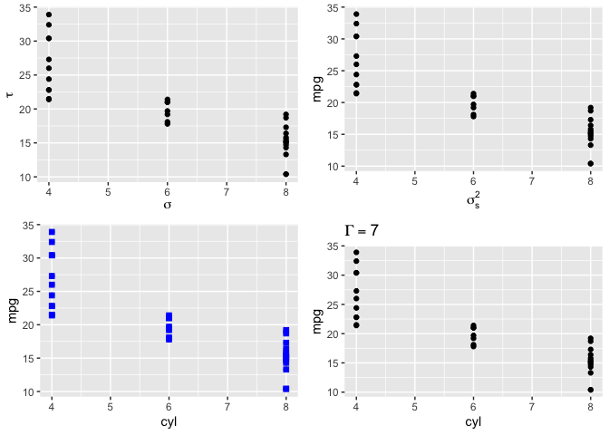

```r
ggarrange(p1, p2, p3, p4, nrow = 2, ncol = 2)
```